# Aggregated Cyber Power Index

Belfer Cyber Initiative

3/31/2020

## Setup

### Compind Package

This script is based mainly on the R Compind package (https://cran.r-project.org/web/packages/Compind/index.html). The package is used to normalize and aggregate indicators.  
Note regarding the terminology: “composite indicator” and “index” are used interchangably.

### Data

The processed data for modelling includes 20 variables and 28 observatons.  
Note: North Korea is removed from the analysis for now, as data points of core variables for this country (such as the GDP) were missing.

```r
CPI <- readRDS("../../data/data_for_modelling/CPI_2020.rds") %>%
  filter(country != "North Korea") # remove North Korea for now because of missing information
```

## Correlation matrix

The matrix below shows the correlation between the cyber power indicators.  
Please refer to the codebook for a description of the indicators.

```r
CPI.cor <- cor(CPI[, -1], method = c("pearson"))
CPI.rcorr <- rcorr(as.matrix(CPI[, -1]), type = c("pearson"))
CPI.coeff = CPI.rcorr$r
CPI.p = CPI.rcorr$P
# summary(CPI.coeff)
kable(CPI.cor [1:14,1:14], digits = 2)
```

|  | ecommerce | ecommerce_capita | patent_application | patent_app_capita | removal_google | freedom_net | infocomm_imp | tech_exports | skilled_employees | internet_use | cyber_prepared | bilat_agreement | critical_infrastructure | state_attacks |
| --- | --- | --- | --- | --- | --- | --- | --- | --- | --- | --- | --- | --- | --- | --- |
| ecommerce | 1.00 | 0.27 | 0.97 | 0.31 | -0.04 | -0.30 | 0.57 | 0.19 | 0.01 | -0.20 | -0.06 | 0.23 | 0.35 | 0.43 |
| ecommerce_capita | 0.27 | 1.00 | 0.20 | 0.56 | -0.16 | 0.51 | 0.53 | 0.28 | 0.55 | 0.59 | 0.25 | 0.29 | 0.07 | -0.17 |
| patent_application | 0.97 | 0.20 | 1.00 | 0.38 | -0.04 | -0.35 | 0.44 | 0.20 | -0.06 | -0.23 | -0.10 | 0.09 | 0.36 | 0.46 |
| patent_app_capita | 0.31 | 0.56 | 0.38 | 1.00 | -0.04 | -0.01 | 0.25 | 0.27 | 0.03 | 0.23 | 0.07 | 0.16 | 0.05 | 0.03 |
| removal_google | -0.04 | -0.16 | -0.04 | -0.04 | 1.00 | -0.25 | -0.04 | -0.12 | -0.42 | -0.08 | 0.02 | -0.08 | 0.15 | 0.75 |
| freedom_net | -0.30 | 0.51 | -0.35 | -0.01 | -0.25 | 1.00 | 0.17 | 0.02 | 0.81 | 0.63 | 0.48 | 0.28 | -0.21 | -0.55 |
| infocomm_imp | 0.57 | 0.53 | 0.44 | 0.25 | -0.04 | 0.17 | 1.00 | 0.16 | 0.33 | 0.12 | 0.13 | 0.45 | 0.32 | 0.06 |
| tech_exports | 0.19 | 0.28 | 0.20 | 0.27 | -0.12 | 0.02 | 0.16 | 1.00 | 0.30 | 0.22 | 0.05 | 0.27 | 0.12 | -0.08 |
| skilled_employees | 0.01 | 0.55 | -0.06 | 0.03 | -0.42 | 0.81 | 0.33 | 0.30 | 1.00 | 0.60 | 0.63 | 0.38 | -0.12 | -0.51 |
| internet_use | -0.20 | 0.59 | -0.23 | 0.23 | -0.08 | 0.63 | 0.12 | 0.22 | 0.60 | 1.00 | 0.55 | 0.12 | -0.22 | -0.25 |
| cyber_prepared | -0.06 | 0.25 | -0.10 | 0.07 | 0.02 | 0.48 | 0.13 | 0.05 | 0.63 | 0.55 | 1.00 | 0.31 | 0.01 | -0.17 |
| bilat_agreement | 0.23 | 0.29 | 0.09 | 0.16 | -0.08 | 0.28 | 0.45 | 0.27 | 0.38 | 0.12 | 0.31 | 1.00 | 0.13 | -0.14 |
| critical_infrastructure | 0.35 | 0.07 | 0.36 | 0.05 | 0.15 | -0.21 | 0.32 | 0.12 | -0.12 | -0.22 | 0.01 | 0.13 | 1.00 | 0.18 |
| state_attacks | 0.43 | -0.17 | 0.46 | 0.03 | 0.75 | -0.55 | 0.06 | -0.08 | -0.51 | -0.25 | -0.17 | -0.14 | 0.18 | 1.00 |

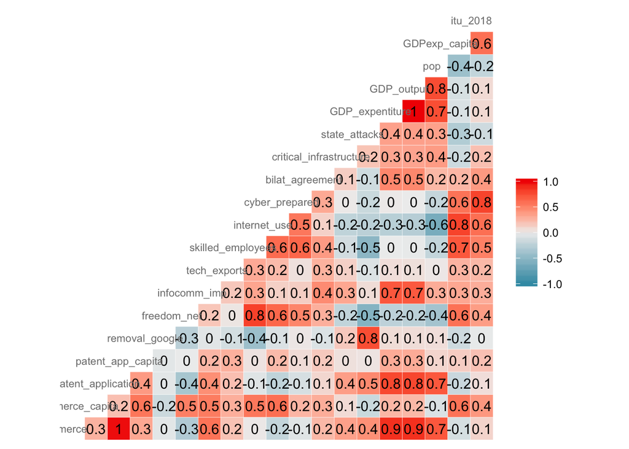

```r
ggcorr(CPI[, -1], method = c("pairwise", "pearson"), label=T, hjust = 0.75, size = 3, color = "grey50")
```

## Normalization

The compind package uses three normalization methods:

- 1 = standardization or z-scores
- 2 = Min-max method
- 3 = Ranking method. If polarity=“POS” ranking is increasing, while if polarity=“NEG” ranking is decreasing

For now, we have used the default (1) z-scores. Removal from google points to the negative direction, all other indicators point to the positive direction.  
Note: this is still a point of discussion, as we are not sure that the polarity of the indicators is correct.

```r
data_norm = normalise_ci(CPI,c(3, 5, 6:14),c("POS","POS","NEG","POS","POS","POS","POS","POS","POS","POS","POS"),method=1,z.mean=0, z.std=1)
summary(data_norm$ci_norm)
```

```
##  ecommerce_capita  patent_app_capita removal_google     freedom_net
##  Min.   :-1.0561   Min.   :-0.5020   Min.   :-5.0537   Min.   :-1.9954
##  1st Qu.:-0.9321   1st Qu.:-0.4645   1st Qu.: 0.1420   1st Qu.:-0.4919
##  Median :-0.3330   Median :-0.3170   Median : 0.2548   Median : 0.3248
##  Mean   : 0.0000   Mean   : 0.0000   Mean   : 0.0000   Mean   : 0.0000
##  3rd Qu.: 0.8464   3rd Qu.:-0.2254   3rd Qu.: 0.2774   3rd Qu.: 0.6682
##  Max.   : 2.0918   Max.   : 4.0770   Max.   : 0.2826   Max.   : 1.3457
##   infocomm_imp      tech_exports     skilled_employees  internet_use
##  Min.   :-0.8316   Min.   :-1.2212   Min.   :-1.9799   Min.   :-2.7251
##  1st Qu.:-0.6266   1st Qu.:-0.6679   1st Qu.:-0.5284   1st Qu.:-0.7095
##  Median :-0.3551   Median :-0.1504   Median : 0.3378   Median : 0.3139
##  Mean   : 0.0000   Mean   : 0.0000   Mean   : 0.0000   Mean   : 0.0000
##  3rd Qu.: 0.2132   3rd Qu.: 0.3493   3rd Qu.: 0.7204   3rd Qu.: 0.7015
##  Max.   : 2.9602   Max.   : 2.4908   Max.   : 1.1391   Max.   : 1.1201
##  cyber_prepared    bilat_agreement   critical_infrastructure
##  Min.   :-3.1747   Min.   :-1.4934   Min.   :-1.56013
##  1st Qu.:-0.4273   1st Qu.:-0.6618   1st Qu.:-0.71190
##  Median : 0.2328   Median :-0.2104   Median :-0.07573
##  Mean   : 0.0000   Mean   : 0.0000   Mean   : 0.00000
##  3rd Qu.: 0.8301   3rd Qu.: 0.3360   3rd Qu.: 0.66646
##  Max.   : 1.0627   Max.   : 3.0682   Max.   : 1.83277
```

## Aggregation

The compind package lists many different methods to choose from. We explored three methods:

- Benefit of the Doubt approach
- Factor analysis
- Min-Max

Other methods methods worth considering are:

- Generalized mean
- Weighting method based on geometric aggregation
- Mazziotta-Pareto Index (MPI) method
- Wroclaw Taxonomic Method

Factor analysis and Min-Max yield to the best results.  
Note: we still have to decide which one to choose and whether or not it is worth exploring additional aggregation methods.

### Benefit of the Doubt approach

```r
CI1 = ci_bod(data_norm$ci_norm,c(1:11))
CPI_CI = data.frame(CPI, CI1_est= CI1$ci_bod_est)
```

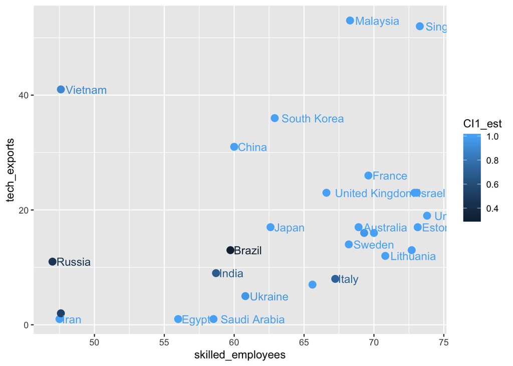

### Factor analysis

```r
CI2 = ci_factor(data_norm$ci_norm,c(1:11),method="CH", dim=3)
summ = summary(as.data.frame(CI2$ci_factor_est))
CPI_CI <- data.frame(CPI_CI, CI2_est= CI2$ci_factor_est)
```

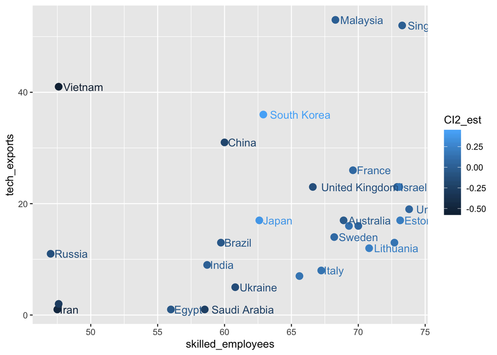

### Min-Max

```r
CI3 = ci_mean_min(data_norm$ci_norm, alpha=0.5, beta=1)
CPI_CI <- data.frame(CPI_CI, CI3_est= CI3$ci_mean_min_est)
```

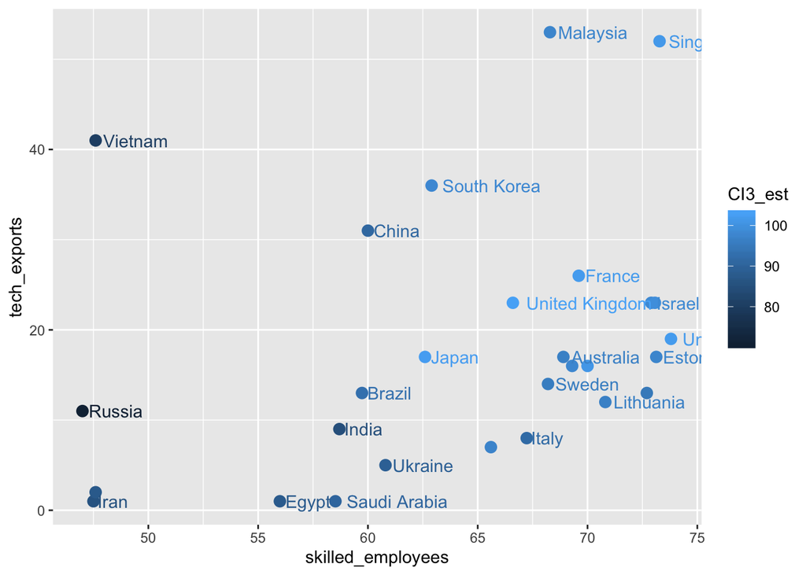

## Sensitivity analysis

Finally, we run a sensitivity analysis with the three cyber power composite indicators created above.

The matrix below shows the correlation between the three cyber power composite indicators computed before, the GDP per capita and the ITU cyber index.  
Note: we expect that our index correlates fairly highly with GDP per capita and the ITU cyber index  
Note: we are still brainstorming additional analyses we should run to check the robustness of our cyber power index, such as:  
* detect outliers of CI * estimate the Kernel distribution of CI

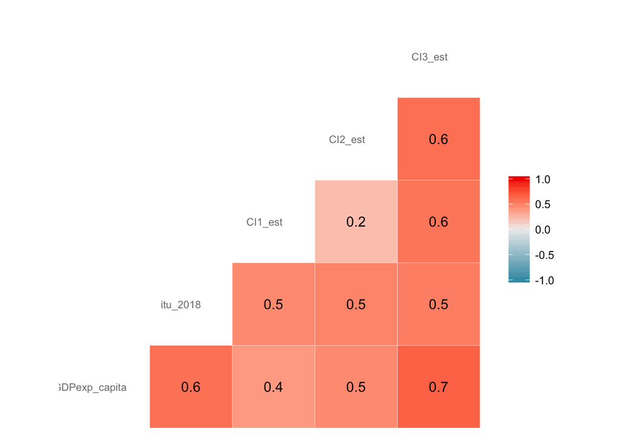